# Modelling Draft 2 - Year Processing Ver - dfN1

## Part 1 - Exploratory Data Analysis and Data Engineering

1. Import Libraries and load the data into the pandas data frame

```python
import numpy as np
import pandas as pd
import matplotlib.pyplot as plt
import seaborn as sns
```

```python
%matplotlib inline
import numpy as np
import pandas as pd
import statsmodels.api as sm
import seaborn as sns
import matplotlib.pyplot as plt
from sklearn.preprocessing import scale, StandardScaler

from sklearn.model_selection import train_test_split, GridSearchCV, cross_val_score
from sklearn.metrics import confusion_matrix, accuracy_score, recall_score, mean_squared_error, r2_score, roc_auc_score, roc_curve, classification_report
from sklearn.linear_model import LogisticRegression
from sklearn.neighbors import KNeighborsClassifier
from sklearn.svm import SVC
from sklearn.neural_network import MLPClassifier
from sklearn.tree import DecisionTreeClassifier
from sklearn.ensemble import RandomForestClassifier
from sklearn.ensemble import GradientBoostingClassifier
from lightgbm import LGBMClassifier
from sklearn.model_selection import KFold
import warnings
warnings.simplefilter(action = "ignore")
```

```python
# conda install -c conda-forge mlxtend
```

```python
from sklearn.preprocessing import StandardScaler
import statsmodels.api as sm
import statsmodels.formula.api as smf
from statsmodels.formula.api import glm

from mlxtend.feature_selection import SequentialFeatureSelector as SFS
from sklearn.linear_model import LogisticRegression as LGR
from sklearn.model_selection import train_test_split

from mlxtend.plotting import plot_sequential_feature_selection as plot_sfs
import matplotlib.pyplot as plt
#import missingno as msno
from sklearn.linear_model import LogisticRegression
from sklearn.metrics import plot_confusion_matrix
from sklearn.metrics import classification_report
from sklearn.metrics import accuracy_score
from sklearn.metrics import confusion_matrix
from sklearn.datasets import make_classification
from sklearn.linear_model import LogisticRegression
from sklearn.model_selection import train_test_split
from sklearn.metrics import roc_curve
from sklearn.metrics import roc_auc_score
from matplotlib import pyplot
import math
```

```python
# conda install -c conda-forge pycaret
```

```python
from sklearn.metrics import brier_score_loss
import numpy as np
import matplotlib.pyplot as plt
import pandas as pd
import seaborn as sns
import warnings
warnings.filterwarnings("ignore")
from pycaret.classification import *
import data_describe as dd
#from IPython.display import display
```

```python
# pip install pycaret
```

## 2. Review data dimension and data type for each feature

```python
dfN1_noMRN.info()
```

[output not shown]

## 3. Check for missing values

```python
dfN1_noMRN.isnull().values.any()
```

```
False
```

### 3.1 Data Cleaning & interpolate

```python
# sns.distplot(merged_df2['INRBC'])
# merged_df2['INRBC'].describe()
```

```python
# print(merged_df2['Patient MRN'].nunique())
# print()
# print(merged_df2[merged_df2['tMN_Patient']==1].nunique())
```

```python
# # Assuming 'A' is the column with null values
# df = merged_df4.dropna(subset=['INRBC'])
```

```python
print(dfN1['Patient MRN'].nunique())
print()
print(dfN1[dfN1['tMN_Patient']==1]['Patient MRN'].nunique())
```

```
24583

148
```

```python
# sns.distplot(df['INRBC'])
# df['INRBC'].describe()
```

```python
# Interpolate for NA value

# df['INRBC'] = df['INRBC'].interpolate()
```

```python
# sns.distplot(df['INRBC'])
# df['INRBC'].describe()
```

```python
# !pip install --upgrade nbconvert
# !pip install --upgrade jinja2
```

```python
# pip show nbconvert
```

```python
dfN1_noMRN.corr()
```

|  | tMN_Patient | HEMATOCRIT -1 | HEMOGLOBIN -1 | LYMPHOCYTE % -1 | LYMPHOCYTE ABS -1 | MCH -1 | MCHC -1 | MCV -1 | MONOCYTE % -1 | MONOCYTE ABS -1 | MPV -1 | NEUTROPHIL % -1 | NEUTROPHIL ABS -1 | PLATELET COUNT -1 | RBC -1 | RDW-CV -1 | RDW-SD -1 | WBC -1 | Married | Female | Age_at_Encounter |
| --- | --- | --- | --- | --- | --- | --- | --- | --- | --- | --- | --- | --- | --- | --- | --- | --- | --- | --- | --- | --- | --- |
| tMN_Patient | 1.000000 | -0.022401 | -0.020647 | -0.014747 | -0.010224 | 0.067886 | 0.005398 | 0.075232 | 0.003502 | -0.011115 | 0.057469 | 0.014081 | -0.006886 | -0.041275 | -0.047014 | 0.010632 | 0.042081 | -0.011775 | 0.013559 | -0.014026 | 0.042973 |
| HEMATOCRIT -1 | -0.022401 | 1.000000 | 0.978345 | 0.015161 | 0.152595 | -0.037471 | -0.073034 | -0.011512 | -0.106707 | 0.078067 | -0.241554 | 0.059564 | 0.101237 | 0.384050 | 0.918723 | -0.331921 | -0.246108 | 0.144175 | 0.009961 | -0.068738 | -0.001753 |
| HEMOGLOBIN -1 | -0.020647 | 0.978345 | 1.000000 | 0.027905 | 0.138916 | 0.063697 | 0.130307 | 0.007597 | -0.095276 | 0.060965 | -0.226003 | 0.043286 | 0.078094 | 0.322383 | 0.888242 | -0.391151 | -0.290946 | 0.118314 | 0.010131 | -0.095801 | -0.026479 |
| LYMPHOCYTE % -1 | -0.014747 | 0.015161 | 0.027905 | 1.000000 | 0.275564 | 0.010142 | 0.072534 | -0.023260 | -0.068093 | -0.225525 | 0.009289 | -0.853475 | -0.384195 | -0.084046 | 0.022904 | -0.114407 | -0.091742 | -0.233895 | -0.036292 | 0.080813 | 0.047056 |
| LYMPHOCYTE ABS -1 | -0.010224 | 0.152595 | 0.138916 | 0.275564 | 1.000000 | -0.025281 | -0.061169 | -0.000587 | -0.094940 | 0.159378 | -0.028497 | -0.202916 | 0.085878 | 0.113384 | 0.141688 | -0.032195 | -0.019513 | 0.479400 | -0.016013 | 0.015175 | 0.022546 |
| MCH -1 | 0.067886 | -0.037471 | 0.063697 | 0.010142 | -0.025281 | 1.000000 | 0.476501 | 0.908991 | 0.046368 | -0.049489 | 0.099036 | -0.002634 | -0.070697 | -0.235014 | -0.389445 | -0.075257 | 0.360378 | -0.076534 | 0.057823 | -0.018224 | 0.121925 |
| MCHC -1 | 0.005398 | -0.073034 | 0.130307 | 0.072534 | -0.061169 | 0.476501 | 1.000000 | 0.070687 | 0.055532 | -0.087171 | 0.077376 | -0.087799 | -0.118277 | -0.301093 | -0.110125 | -0.309188 | -0.244932 | -0.129074 | -0.002194 | -0.126550 | -0.122705 |
| MCV -1 | 0.075232 | -0.011512 | 0.007597 | -0.023260 | -0.000587 | 0.908991 | 0.070687 | 1.000000 | 0.028308 | -0.015184 | 0.079011 | 0.037497 | -0.025262 | -0.130088 | -0.394292 | 0.055684 | 0.521776 | -0.026838 | 0.065302 | 0.038947 | 0.196669 |
| MONOCYTE % -1 | 0.003502 | -0.106707 | -0.095276 | -0.068093 | -0.094940 | 0.046368 | 0.055532 | 0.028308 | 1.000000 | 0.365778 | 0.104116 | -0.320127 | -0.224805 | -0.118083 | -0.112142 | 0.048395 | 0.034173 | -0.176513 | 0.014263 | -0.051616 | 0.008058 |
| MONOCYTE ABS -1 | -0.011115 | 0.078067 | 0.060965 | -0.225525 | 0.159378 | -0.049489 | -0.087171 | -0.015184 | 0.365778 | 1.000000 | -0.015058 | 0.043977 | 0.436720 | 0.149558 | 0.076228 | 0.059069 | 0.036435 | 0.556816 | 0.020682 | -0.053155 | 0.007040 |
| MPV -1 | 0.057469 | -0.241554 | -0.226003 | 0.009289 | -0.028497 | 0.099036 | 0.077376 | 0.079011 | 0.104116 | -0.015058 | 1.000000 | -0.071655 | -0.073815 | -0.409369 | -0.251100 | 0.131174 | 0.132554 | -0.067728 | -0.001837 | -0.018314 | 0.004027 |
| NEUTROPHIL % -1 | 0.014081 | 0.059564 | 0.043286 | -0.853475 | -0.202916 | -0.002634 | -0.087799 | 0.037497 | -0.320127 | 0.043977 | -0.071655 | 1.000000 | 0.450748 | 0.159835 | 0.043128 | 0.081392 | 0.081156 | 0.264516 | 0.012515 | -0.053727 | -0.056778 |
| NEUTROPHIL ABS -1 | -0.006886 | 0.101237 | 0.078094 | -0.384195 | 0.085878 | -0.070697 | -0.118277 | -0.025262 | -0.224805 | 0.436720 | -0.073815 | 0.450748 | 1.000000 | 0.211342 | 0.103173 | 0.064609 | 0.044333 | 0.895207 | 0.011238 | -0.031274 | -0.033764 |
| PLATELET COUNT -1 | -0.041275 | 0.384050 | 0.322383 | -0.084046 | 0.113384 | -0.235014 | -0.301093 | -0.130088 | -0.118083 | 0.149558 | -0.409369 | 0.159835 | 0.211342 | 1.000000 | 0.409835 | -0.021512 | -0.061628 | 0.223954 | -0.036519 | 0.114063 | -0.065810 |
| RBC -1 | -0.047014 | 0.918723 | 0.888242 | 0.022904 | 0.141688 | -0.389445 | -0.110125 | -0.394292 | -0.112142 | 0.076228 | -0.251100 | 0.043128 | 0.103173 | 0.409835 | 1.000000 | -0.304717 | -0.408004 | 0.143263 | -0.015212 | -0.077959 | -0.079376 |
| RDW-CV -1 | 0.010632 | -0.331921 | -0.391151 | -0.114407 | -0.032195 | -0.075257 | -0.309188 | 0.055684 | 0.048395 | 0.059069 | 0.131174 | 0.081392 | 0.064609 | -0.021512 | -0.304717 | 1.000000 | 0.850903 | 0.048986 | 0.003296 | -0.006288 | 0.011191 |
| RDW-SD -1 | 0.042081 | -0.246108 | -0.290946 | -0.091742 | -0.019513 | 0.360378 | -0.244932 | 0.521776 | 0.034173 | 0.036435 | 0.132554 | 0.081156 | 0.044333 | -0.061628 | -0.408004 | 0.850903 | 1.000000 | 0.031566 | 0.034877 | 0.013036 | 0.116127 |
| WBC -1 | -0.011775 | 0.144175 | 0.118314 | -0.233895 | 0.479400 | -0.076534 | -0.129074 | -0.026838 | -0.176513 | 0.556816 | -0.067728 | 0.264516 | 0.895207 | 0.223954 | 0.143263 | 0.048986 | 0.031566 | 1.000000 | 0.007972 | -0.026583 | -0.017254 |
| Married | 0.013559 | 0.009961 | 0.010131 | -0.036292 | -0.016013 | 0.057823 | -0.002194 | 0.065302 | 0.014263 | 0.020682 | -0.001837 | 0.012515 | 0.011238 | -0.036519 | -0.015212 | 0.003296 | 0.034877 | 0.007972 | 1.000000 | -0.134824 | 0.236318 |
| Female | -0.014026 | -0.068738 | -0.095801 | 0.080813 | 0.015175 | -0.018224 | -0.126550 | 0.038947 | -0.051616 | -0.053155 | -0.018314 | -0.053727 | -0.031274 | 0.114063 | -0.077959 | -0.006288 | 0.013036 | -0.026583 | -0.134824 | 1.000000 | -0.028861 |
| Age_at_Encounter | 0.042973 | -0.001753 | -0.026479 | 0.047056 | 0.022546 | 0.121925 | -0.122705 | 0.196669 | 0.008058 | 0.007040 | 0.004027 | -0.056778 | -0.033764 | -0.065810 | -0.079376 | 0.011191 | 0.116127 | -0.017254 | 0.236318 | -0.028861 | 1.000000 |

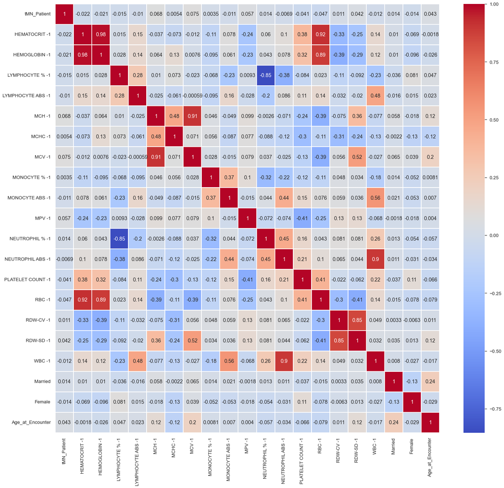

```python
sns.set(font_scale=1.2)  # Adjust the font scale for better readability

plt.figure(figsize=(24, 22))  # Adjust the figsize parameter for the desired size

sns.heatmap(dfN1_noMRN.corr(), annot=True, linewidths=0.01, cmap='coolwarm')

plt.show()
```

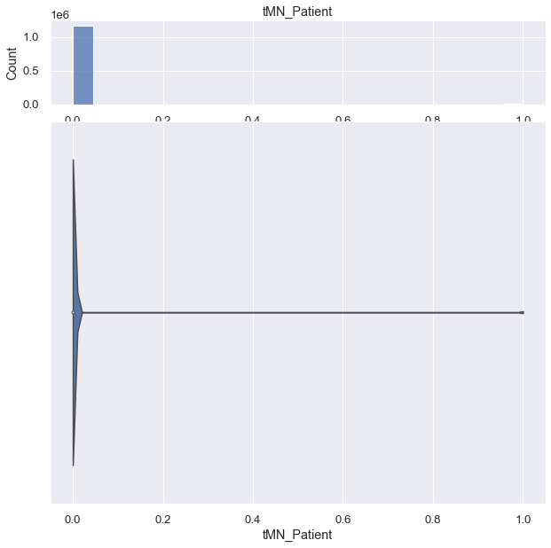

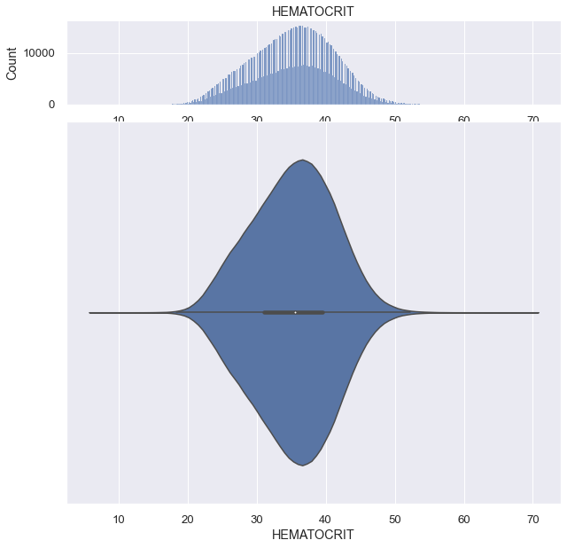

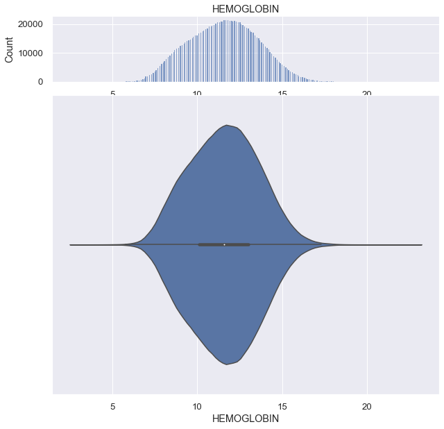

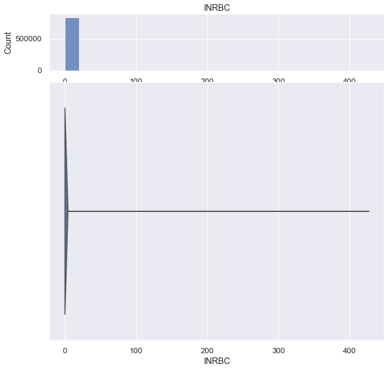

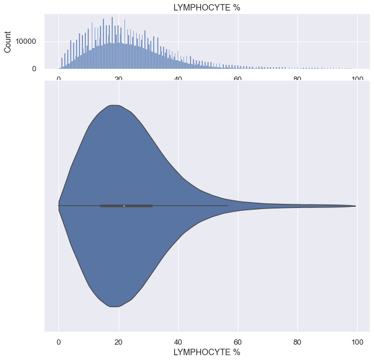

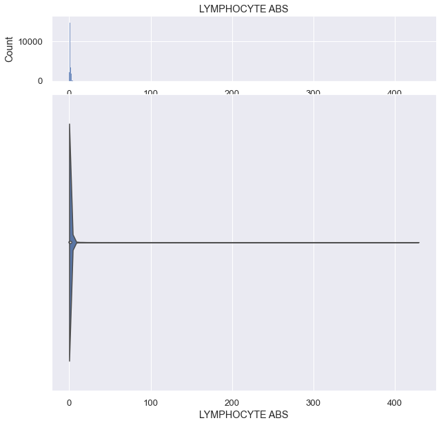

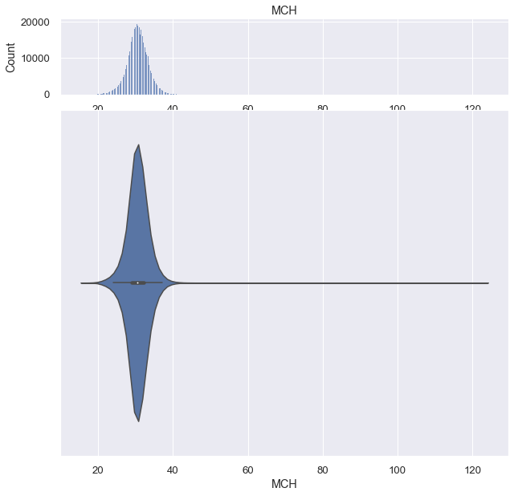

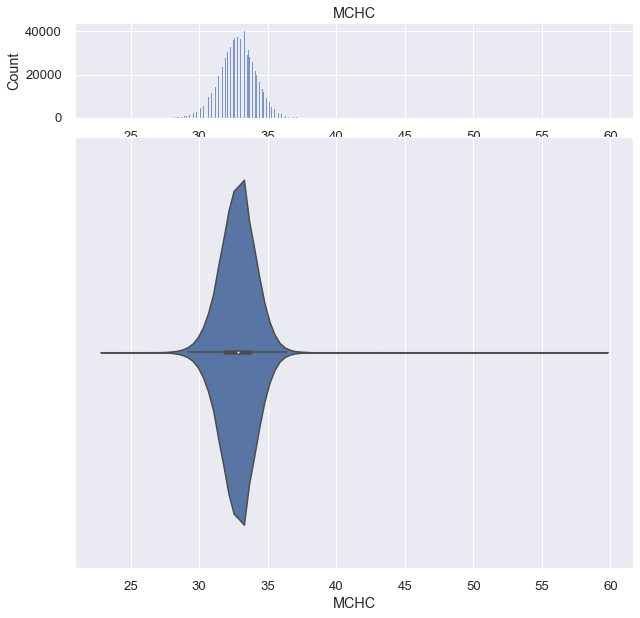

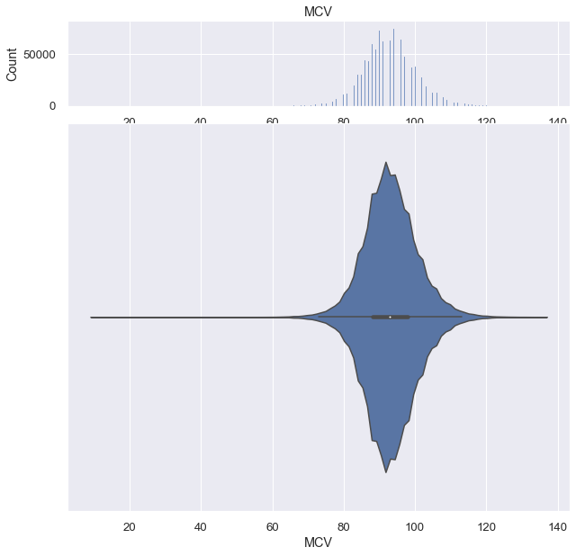

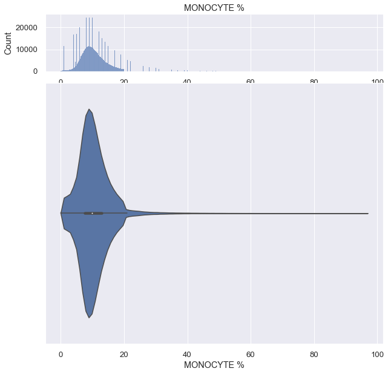

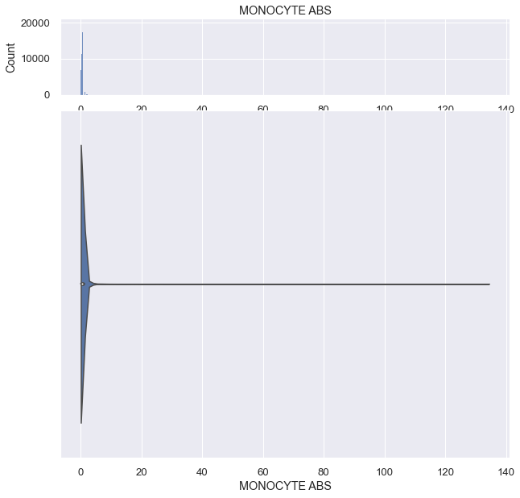

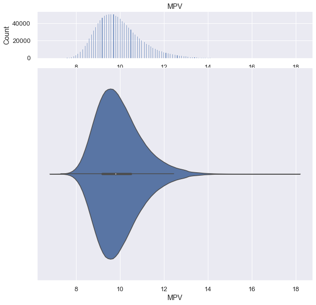

[10 more figures not shown]

```python
# for col in df2.columns:
#     display(dd.distribution(df2, plot_all = True).plot_distribution(col))
```

## Backward Selection

Start with all features

```python
# from imblearn.over_sampling import SMOTE
# from imblearn.under_sampling import RandomUnderSampler
# from imblearn.pipeline import Pipeline
# from sklearn.model_selection import train_test_split
# from sklearn.linear_model import LogisticRegression
# from sklearn.metrics import classification_report

# # Assume 'X' is your feature matrix and 'y' is your target variable
# # Split the data into training and testing sets
# X_train, X_test, y_train, y_test = train_test_split(X, y, test_size=0.2, random_state=42)

# # Define the resampling strategies
# over_sampler = SMOTE(sampling_strategy=0.5)  # Adjust the sampling strategy as needed
# under_sampler = RandomUnderSampler(sampling_strategy=0.8)  # Adjust the sampling strategy as needed

# # Define the classifier
# classifier = LogisticRegression(random_state=42)

# # Create a pipeline with resampling and classification steps
# pipeline = Pipeline([
#     ('oversample', over_sampler),
#     ('undersample', under_sampler),
#     ('classifier', classifier)
# ])

# # Fit the pipeline on the training data
# pipeline.fit(X_train, y_train)

# # Make probability predictions on the test set
# y_proba = pipeline.predict_proba(X_test)

# # Extract the probability estimates for the positive class (y=1)
# positive_class_probs = y_proba[:, 1]

# # You can use these probabilities for further analysis or setting a threshold for classification

# # Evaluate the model
# y_pred = pipeline.predict(X_test)
# print(classification_report(y_test, y_pred))
```

```python
dfN1_scale
```

|  | Encounter Date | tMN_Patient | HEMATOCRIT -1 | HEMOGLOBIN -1 | LYMPHOCYTE % -1 | LYMPHOCYTE ABS -1 | MCH -1 | MCHC -1 | MCV -1 | MONOCYTE % -1 | MONOCYTE ABS -1 | MPV -1 | NEUTROPHIL % -1 | NEUTROPHIL ABS -1 | PLATELET COUNT -1 | RBC -1 | RDW-CV -1 | RDW-SD -1 | WBC -1 | Birth Date | Married | Female | Age_at_Encounter |
| --- | --- | --- | --- | --- | --- | --- | --- | --- | --- | --- | --- | --- | --- | --- | --- | --- | --- | --- | --- | --- | --- | --- | --- |
| 0 | 2022-09-14 00:00:00 | 0 | 0.205384 | 0.212370 | -0.659191 | -0.301006 | -0.294310 | -0.001679 | -0.312388 | -0.041121 | -0.273862 | -0.736232 | 0.585739 | -0.237296 | 0.215182 | 0.298946 | -0.359616 | -0.478345 | -0.352262 | 1950-10-31 | 0 | 1 | 0.763598 |
| 1 | 2022-09-14 00:00:00 | 0 | 0.205384 | 0.212370 | -0.659191 | -0.301006 | -0.294310 | -0.001679 | -0.312388 | -0.041121 | -0.273862 | -0.736232 | 0.585739 | -0.237296 | 0.215182 | 0.298946 | -0.359616 | -0.478345 | -0.352262 | 1950-10-31 | 0 | 1 | 0.763598 |
| 2 | 2022-09-14 00:00:00 | 0 | 0.205384 | 0.212370 | -0.659191 | -0.301006 | -0.294310 | -0.001679 | -0.312388 | -0.041121 | -0.273862 | -0.736232 | 0.585739 | -0.237296 | 0.215182 | 0.298946 | -0.359616 | -0.478345 | -0.352262 | 1950-10-31 | 0 | 1 | 0.763598 |
| 3 | 2022-09-14 00:00:00 | 0 | 0.205384 | 0.212370 | -0.659191 | -0.301006 | -0.294310 | -0.001679 | -0.312388 | -0.041121 | -0.273862 | -0.736232 | 0.585739 | -0.237296 | 0.215182 | 0.298946 | -0.359616 | -0.478345 | -0.352262 | 1950-10-31 | 0 | 1 | 0.763598 |
| 4 | 2022-09-14 00:00:00 | 0 | 0.205384 | 0.212370 | -0.659191 | -0.301006 | -0.294310 | -0.001679 | -0.312388 | -0.041121 | -0.273862 | -0.736232 | 0.585739 | -0.237296 | 0.215182 | 0.298946 | -0.359616 | -0.478345 | -0.352262 | 1950-10-31 | 0 | 1 | 0.763598 |
| ... | ... | ... | ... | ... | ... | ... | ... | ... | ... | ... | ... | ... | ... | ... | ... | ... | ... | ... | ... | ... | ... | ... | ... |
| 23759960 | 2023-03-10 07:30:00 | 0 | -0.825472 | -0.850029 | -0.226671 | -0.466080 | -1.382288 | -0.232995 | -1.484919 | 2.528034 | -0.627422 | 2.381321 | -1.574280 | -0.800761 | -0.857387 | -0.230200 | -0.650375 | -1.118249 | -0.891810 | 1952-07-27 | 1 | 1 | 0.690916 |
| 23759961 | 2023-03-10 07:30:00 | 0 | -0.825472 | -0.850029 | -0.226671 | -0.466080 | -1.382288 | -0.232995 | -1.484919 | 2.528034 | -0.627422 | 2.381321 | -1.574280 | -0.800761 | -0.857387 | -0.230200 | -0.650375 | -1.118249 | -0.891810 | 1952-07-27 | 1 | 1 | 0.690916 |
| 23759962 | 2023-03-10 07:30:00 | 0 | -0.825472 | -0.850029 | -0.226671 | -0.466080 | -1.382288 | -0.232995 | -1.484919 | 2.528034 | -0.627422 | 2.381321 | -1.574280 | -0.800761 | -0.857387 | -0.230200 | -0.650375 | -1.118249 | -0.891810 | 1952-07-27 | 1 | 1 | 0.690916 |
| 23759963 | 2023-03-10 07:30:00 | 0 | -0.825472 | -0.850029 | -0.226671 | -0.466080 | -1.382288 | -0.232995 | -1.484919 | 2.528034 | -0.627422 | 2.381321 | -1.574280 | -0.800761 | -0.857387 | -0.230200 | -0.650375 | -1.118249 | -0.891810 | 1952-07-27 | 1 | 1 | 0.690916 |
| 23759964 | 2023-03-10 07:30:00 | 0 | -0.825472 | -0.850029 | -0.226671 | -0.466080 | -1.382288 | -0.232995 | -1.484919 | 2.528034 | -0.627422 | 2.381321 | -1.574280 | -0.800761 | -0.857387 | -0.230200 | -0.650375 | -1.118249 | -0.891810 | 1952-07-27 | 1 | 1 | 0.690916 |

23759965 rows × 23 columns

```python
df=dfN1_scale
```

```python
df.rename(columns=lambda x: x.replace(' ', ''), inplace=True)

df.columns = df.columns.str.replace('_', '')

df.columns = df.columns.str.replace('-', '')

df.columns = df.columns.str.replace('%', 'PCT')
```

```python
df.info()
```

[output not shown]

```python
df.columns
```

[output not shown]

```python
# colnamelist = ['HEMATOCRIT', 'HEMOGLOBIN', 'INRBC', 'LYMPHOCYTE%', 'LYMPHOCYTEABS', 'MCH', 'MCHC', 'MCV', 'MONOCYTE%',
#                'MONOCYTEABS', 'MPV', 'NEUTROPHIL%', 'NEUTROPHILABS', 'PLATELETCOUNT', 'RBC', 'RDWCV', 'RDWSD', 'WBC',
#                'Female', 'Married', 'AgeatEncounter']

# colnamelist_without_quotes = [col.replace("'", "") for col in colnamelist]

# print(colnamelist_without_quotes)
```

[output not shown]

```python
model_GLM = glm(formula = 'tMNPatient ~ HEMATOCRIT + HEMOGLOBIN + INRBC + LYMPHOCYTEPCT + LYMPHOCYTEABS + MCH + MCHC + MCV + MONOCYTEPCT + MONOCYTEABS + MPV + NEUTROPHILPCT + NEUTROPHILABS + PLATELETCOUNT + RBC + RDWCV + RDWSD + WBC + Female + Married + AgeatEncounter'
                ,data = df,
                family = sm.families.Binomial()).fit()
print(model_GLM.summary())
print()
print("Model AIC: " , model_GLM.aic)
```

[output not shown]

```python
# Remove INRBC

model_GLM = glm(formula = 'tMNPatient ~ HEMATOCRIT + HEMOGLOBIN + LYMPHOCYTEPCT + LYMPHOCYTEABS + MCH + MCHC + MCV + MONOCYTEPCT + MONOCYTEABS + MPV + NEUTROPHILPCT + NEUTROPHILABS + PLATELETCOUNT + RBC + RDWCV + RDWSD + WBC + Female + Married + AgeatEncounter'
                ,data = df,
                family = sm.families.Binomial()).fit()
print(model_GLM.summary())
print()
print("Model AIC: " , model_GLM.aic)
```

```
                 Generalized Linear Model Regression Results
==============================================================================
Dep. Variable:             tMNPatient   No. Observations:               841717
Model:                            GLM   Df Residuals:                   841696
Model Family:                Binomial   Df Model:                           20
Link Function:                  Logit   Scale:                          1.0000
Method:                          IRLS   Log-Likelihood:                -33404.
Date:                Tue, 21 Nov 2023   Deviance:                       66807.
Time:                        15:36:14   Pearson chi2:                 5.37e+08
No. Iterations:                     9   Pseudo R-squ. (CS):           0.007601
Covariance Type:            nonrobust
==================================================================================
                     coef    std err          z      P>|z|      [0.025      0.975]
----------------------------------------------------------------------------------
Intercept         -5.6829      0.035   -163.442      0.000      -5.751      -5.615
HEMATOCRIT        -0.2874      0.349     -0.823      0.411      -0.972       0.397
HEMOGLOBIN         0.6351      0.338      1.877      0.061      -0.028       1.298
LYMPHOCYTEPCT      0.3776      0.034     11.001      0.000       0.310       0.445
LYMPHOCYTEABS     -0.4736      0.068     -6.981      0.000      -0.607      -0.341
MCH               -1.6893      0.240     -7.026      0.000      -2.161      -1.218
MCHC               0.7095      0.122      5.821      0.000       0.471       0.948
MCV                1.4890      0.215      6.940      0.000       1.069       1.910
MONOCYTEPCT        0.0776      0.016      4.717      0.000       0.045       0.110
MONOCYTEABS        0.0239      0.011      2.243      0.025       0.003       0.045
MPV                0.1074      0.012      8.635      0.000       0.083       0.132
NEUTROPHILPCT      0.1888      0.037      5.041      0.000       0.115       0.262
NEUTROPHILABS     -0.0127      0.051     -0.250      0.803      -0.113       0.087
PLATELETCOUNT     -0.4321      0.020    -21.293      0.000      -0.472      -0.392
RBC               -0.7314      0.155     -4.709      0.000      -1.036      -0.427
RDWCV              0.2604      0.040      6.484      0.000       0.182       0.339
RDWSD             -0.1406      0.044     -3.200      0.001      -0.227      -0.054
WBC                0.0259      0.067      0.385      0.700      -0.106       0.158
Female             0.1534      0.027      5.720      0.000       0.101       0.206
Married            0.2695      0.031      8.568      0.000       0.208       0.331
AgeatEncounter     0.3540      0.015     23.524      0.000       0.325       0.384
==================================================================================

Model AIC:  66849.41957419498
```

```python
# Remove NEUTROPHILABS

model_GLM = glm(formula = 'tMNPatient ~ HEMATOCRIT + HEMOGLOBIN + LYMPHOCYTEPCT + LYMPHOCYTEABS + MCH + MCHC + MCV + MONOCYTEPCT + MONOCYTEABS + MPV + NEUTROPHILPCT + PLATELETCOUNT + RBC + RDWCV + RDWSD + WBC + Female + Married + AgeatEncounter'
                ,data = df,
                family = sm.families.Binomial()).fit()
print(model_GLM.summary())
print()
print("Model AIC: " , model_GLM.aic)
```

```
                 Generalized Linear Model Regression Results
==============================================================================
Dep. Variable:             tMNPatient   No. Observations:               841717
Model:                            GLM   Df Residuals:                   841697
Model Family:                Binomial   Df Model:                           19
Link Function:                  Logit   Scale:                          1.0000
Method:                          IRLS   Log-Likelihood:                -33404.
Date:                Tue, 21 Nov 2023   Deviance:                       66807.
Time:                        15:36:47   Pearson chi2:                 5.39e+08
No. Iterations:                     9   Pseudo R-squ. (CS):           0.007601
Covariance Type:            nonrobust
==================================================================================
                     coef    std err          z      P>|z|      [0.025      0.975]
----------------------------------------------------------------------------------
Intercept         -5.6829      0.035   -163.444      0.000      -5.751      -5.615
HEMATOCRIT        -0.2874      0.349     -0.823      0.411      -0.972       0.397
HEMOGLOBIN         0.6349      0.338      1.876      0.061      -0.028       1.298
LYMPHOCYTEPCT      0.3747      0.032     11.548      0.000       0.311       0.438
LYMPHOCYTEABS     -0.4653      0.060     -7.741      0.000      -0.583      -0.348
MCH               -1.6891      0.240     -7.026      0.000      -2.160      -1.218
MCHC               0.7095      0.122      5.820      0.000       0.471       0.948
MCV                1.4890      0.215      6.940      0.000       1.068       1.909
MONOCYTEPCT        0.0764      0.016      4.839      0.000       0.045       0.107
MONOCYTEABS        0.0258      0.008      3.276      0.001       0.010       0.041
MPV                0.1074      0.012      8.636      0.000       0.083       0.132
NEUTROPHILPCT      0.1854      0.035      5.347      0.000       0.117       0.253
PLATELETCOUNT     -0.4322      0.020    -21.305      0.000      -0.472      -0.392
RBC               -0.7312      0.155     -4.708      0.000      -1.036      -0.427
RDWCV              0.2605      0.040      6.487      0.000       0.182       0.339
RDWSD             -0.1407      0.044     -3.203      0.001      -0.227      -0.055
WBC                0.0094      0.020      0.461      0.645      -0.031       0.049
Female             0.1535      0.027      5.722      0.000       0.101       0.206
Married            0.2694      0.031      8.567      0.000       0.208       0.331
AgeatEncounter     0.3540      0.015     23.523      0.000       0.325       0.384
==================================================================================

Model AIC:  66847.46902219791
```

```python
# Remove WBC

model_GLM = glm(formula = 'tMNPatient ~ HEMATOCRIT + HEMOGLOBIN + LYMPHOCYTEPCT + LYMPHOCYTEABS + MCH + MCHC + MCV + MONOCYTEPCT + MONOCYTEABS + MPV + NEUTROPHILPCT + PLATELETCOUNT + RBC + RDWCV + RDWSD + Female + Married + AgeatEncounter'
                ,data = df,
                family = sm.families.Binomial()).fit()
print(model_GLM.summary())
print()
print("Model AIC: " , model_GLM.aic)
```

```
                 Generalized Linear Model Regression Results
==============================================================================
Dep. Variable:             tMNPatient   No. Observations:               841717
Model:                            GLM   Df Residuals:                   841698
Model Family:                Binomial   Df Model:                           18
Link Function:                  Logit   Scale:                          1.0000
Method:                          IRLS   Log-Likelihood:                -33404.
Date:                Tue, 21 Nov 2023   Deviance:                       66808.
Time:                        15:37:11   Pearson chi2:                 5.39e+08
No. Iterations:                     9   Pseudo R-squ. (CS):           0.007601
Covariance Type:            nonrobust
==================================================================================
                     coef    std err          z      P>|z|      [0.025      0.975]
----------------------------------------------------------------------------------
Intercept         -5.6827      0.035   -163.451      0.000      -5.751      -5.615
HEMATOCRIT        -0.2849      0.349     -0.816      0.415      -0.969       0.400
HEMOGLOBIN         0.6330      0.338      1.871      0.061      -0.030       1.296
LYMPHOCYTEPCT      0.3720      0.032     11.657      0.000       0.309       0.435
LYMPHOCYTEABS     -0.4543      0.055     -8.264      0.000      -0.562      -0.347
MCH               -1.6906      0.240     -7.033      0.000      -2.162      -1.219
MCHC               0.7104      0.122      5.829      0.000       0.472       0.949
MCV                1.4897      0.215      6.944      0.000       1.069       1.910
MONOCYTEPCT        0.0748      0.015      4.860      0.000       0.045       0.105
MONOCYTEABS        0.0277      0.007      4.031      0.000       0.014       0.041
MPV                0.1073      0.012      8.631      0.000       0.083       0.132
NEUTROPHILPCT      0.1850      0.035      5.337      0.000       0.117       0.253
PLATELETCOUNT     -0.4322      0.020    -21.297      0.000      -0.472      -0.392
RBC               -0.7323      0.155     -4.717      0.000      -1.037      -0.428
RDWCV              0.2605      0.040      6.486      0.000       0.182       0.339
RDWSD             -0.1406      0.044     -3.201      0.001      -0.227      -0.055
Female             0.1532      0.027      5.714      0.000       0.101       0.206
Married            0.2694      0.031      8.568      0.000       0.208       0.331
AgeatEncounter     0.3540      0.015     23.522      0.000       0.325       0.384
==================================================================================

Model AIC:  66845.67759713714
```

```python
# Remove HCT

model_GLM = glm(formula = 'tMNPatient ~ HEMOGLOBIN + LYMPHOCYTEPCT + LYMPHOCYTEABS + MCH + MCHC + MCV + MONOCYTEPCT + MONOCYTEABS + MPV + NEUTROPHILPCT + PLATELETCOUNT + RBC + RDWCV + RDWSD + Female + Married + AgeatEncounter'
                ,data = df,
                family = sm.families.Binomial()).fit()
print(model_GLM.summary())
print()
print("Model AIC: " , model_GLM.aic)
```

```
                 Generalized Linear Model Regression Results
==============================================================================
Dep. Variable:             tMNPatient   No. Observations:               841717
Model:                            GLM   Df Residuals:                   841699
Model Family:                Binomial   Df Model:                           17
Link Function:                  Logit   Scale:                          1.0000
Method:                          IRLS   Log-Likelihood:                -33404.
Date:                Tue, 21 Nov 2023   Deviance:                       66808.
Time:                        15:37:35   Pearson chi2:                 5.27e+08
No. Iterations:                     9   Pseudo R-squ. (CS):           0.007600
Covariance Type:            nonrobust
==================================================================================
                     coef    std err          z      P>|z|      [0.025      0.975]
----------------------------------------------------------------------------------
Intercept         -5.6827      0.035   -163.458      0.000      -5.751      -5.615
HEMOGLOBIN         0.3785      0.130      2.902      0.004       0.123       0.634
LYMPHOCYTEPCT      0.3714      0.032     11.645      0.000       0.309       0.434
LYMPHOCYTEABS     -0.4530      0.055     -8.252      0.000      -0.561      -0.345
MCH               -1.6813      0.240     -7.001      0.000      -2.152      -1.211
MCHC               0.7563      0.108      6.999      0.000       0.545       0.968
MCV                1.4688      0.213      6.890      0.000       1.051       1.887
MONOCYTEPCT        0.0748      0.015      4.861      0.000       0.045       0.105
MONOCYTEABS        0.0277      0.007      4.033      0.000       0.014       0.041
MPV                0.1073      0.012      8.627      0.000       0.083       0.132
NEUTROPHILPCT      0.1851      0.035      5.339      0.000       0.117       0.253
PLATELETCOUNT     -0.4321      0.020    -21.291      0.000      -0.472      -0.392
RBC               -0.7753      0.146     -5.323      0.000      -1.061      -0.490
RDWCV              0.2612      0.040      6.507      0.000       0.183       0.340
RDWSD             -0.1404      0.044     -3.197      0.001      -0.227      -0.054
Female             0.1523      0.027      5.687      0.000       0.100       0.205
Married            0.2696      0.031      8.573      0.000       0.208       0.331
AgeatEncounter     0.3536      0.015     23.510      0.000       0.324       0.383
==================================================================================

Model AIC:  66844.34411120975
```

### Graph and plot affect of forward selection

```python
from mlxtend.feature_selection import SequentialFeatureSelector as SFS
from mlxtend.classifier import LogisticRegression as LGR
from mlxtend.plotting import plot_sequential_feature_selection as plot_sfs
import matplotlib.pyplot as plt
```

```python
import mlxtend
print(mlxtend.__version__)
```

```
0.23.0
```

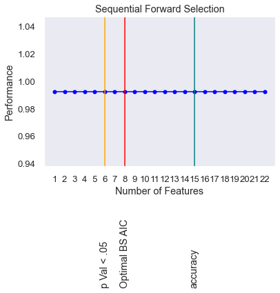

```python
# Forward selection, forward=True

X = df.drop(['tMNPatient'], axis=1)
y = df['tMNPatient']

x_columns = tuple(X.columns)

# Use LogisticRegression without specifying max_iter
sfs = SFS(LogisticRegression(),
          k_features='best',
          forward=True,
          floating=False,
          verbose=0,
          scoring='accuracy',
          cv=0)

# Remove custom_feature_names argument
sfs = sfs.fit(X, y)

fig1 = plot_sfs(sfs.get_metric_dict(confidence_interval=0.95), kind='std_err')

plt.title('Sequential Forward Selection')
plt.axvline(x=6, color='orange')
plt.axvline(x=8, color='red')
plt.axvline(x=15, color='teal')
plt.text(5.5, .851, 'p Val < .05', rotation=90)
plt.text(7.5, .851, 'Optimal BS AIC', rotation=90)
plt.text(14.5, .851, 'accuracy', rotation=90)
plt.grid()
plt.show()
```

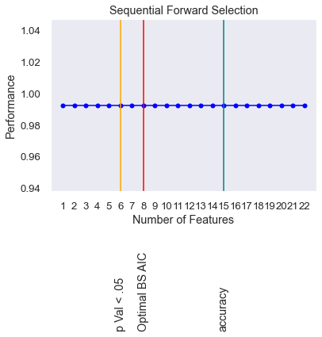

```python
# Backward selection, forward=False

X = df.drop(['tMNPatient'], axis=1)
y = df['tMNPatient']

x_columns = tuple(X.columns)

# Use LogisticRegression without specifying max_iter
sfs = SFS(LogisticRegression(),
          k_features='best',
          forward=False,
          floating=False,
          verbose=0,
          scoring='accuracy',
          cv=0)

# Remove custom_feature_names argument
sfs = sfs.fit(X, y)

fig1 = plot_sfs(sfs.get_metric_dict(confidence_interval=0.95), kind='std_err')

plt.title('Sequential Forward Selection')
plt.axvline(x=6, color='orange')
plt.axvline(x=8, color='red')
plt.axvline(x=15, color='teal')
plt.text(5.5, .851, 'p Val < .05', rotation=90)
plt.text(7.5, .851, 'Optimal BS AIC', rotation=90)
plt.text(14.5, .851, 'accuracy', rotation=90)
plt.grid()
plt.show()
```

for above, the graph results shows a straight line. Why? this is the plot for forward selection. are those features not meaningful at all?

Several reasons could contribute to a lack of improvement in accuracy:

Feature Redundancy: The features you selected might contain redundant information, meaning that adding more features doesn't contribute much to the model.

Overfitting: Adding more features could lead to overfitting, where the model starts to memorize the training data instead of learning general patterns.

Irrelevant Features: Some of the added features might not be relevant to the target variable, and including them could even degrade performance.

To address this, you might consider:

Feature Importance: Use feature importance techniques to identify which features contribute the most to the model.

Domain Knowledge: Consult with domain experts to understand the significance of each feature and whether adding more features makes sense.

Regularization: If overfitting is a concern, consider using regularization techniques in your logistic regression model.

Different Models: Try using different models or algorithms that might capture complex relationships better.

Remember that the effectiveness of feature selection depends on the nature of the data and the problem you're trying to solve. If the initial set of features already provides good performance, adding more features may not necessarily improve results.

for the graph above,what is the y-axis mean? the y-axis is around 0.99, how to interpret?

In the context of sequential forward selection (SFS) for feature selection, the y-axis typically represents the performance metric being optimized, which, in your case, is accuracy. The value on the y-axis indicates the accuracy of the model using the selected subset of features.

Interpreting the y-axis value:

High Accuracy: A value close to 1.0 (or 100%) suggests that the model is making accurate predictions on the dataset.

Overfitting Concerns: However, extremely high accuracy values may also raise concerns about overfitting, where the model is fitting the training data too closely and may not generalize well to new, unseen data.

To interpret the results more comprehensively:

Look for a point on the graph where the accuracy starts to plateau or doesn't increase significantly with the addition of more features. This could indicate that the initial subset of features is sufficiently informative, and adding more features doesn't contribute much to the model's accuracy.

Consider using cross-validation to obtain a more robust estimate of model performance.

If you provide more details about the specific values on the y-axis and the structure of your graph, I can provide more tailored insights.

## 5) Modeling

```python
X_resampled
```

|  | HEMATOCRIT -1 | HEMOGLOBIN -1 | LYMPHOCYTE % -1 | LYMPHOCYTE ABS -1 | MCH -1 | MCHC -1 | MCV -1 | MONOCYTE % -1 | MONOCYTE ABS -1 | MPV -1 | NEUTROPHIL % -1 | NEUTROPHIL ABS -1 | PLATELET COUNT -1 | RBC -1 | RDW-CV -1 | RDW-SD -1 | WBC -1 | Married | Female | Age_at_Encounter |
| --- | --- | --- | --- | --- | --- | --- | --- | --- | --- | --- | --- | --- | --- | --- | --- | --- | --- | --- | --- | --- |
| 13255605 | -0.229508 | -0.125666 | -0.477407 | -0.315155 | 1.320108 | 0.460954 | 1.250986 | -0.947882 | -0.711602 | -0.186076 | 0.782105 | -0.351386 | -0.848374 | -0.664371 | 1.821083 | 2.032792 | -0.496141 | 1 | 0 | 0.290936 |
| 8846024 | 0.430884 | 0.791860 | 1.647581 | 1.005436 | 2.267702 | 1.617536 | 1.641830 | -0.479389 | -0.071829 | 0.730852 | -1.159108 | -0.253594 | -0.929493 | -0.270903 | -1.159205 | -0.381390 | 0.151316 | 0 | 0 | -2.130513 |
| 17755524 | -1.083186 | -1.139774 | -0.477407 | -0.131216 | 0.688379 | -0.464312 | 0.990424 | 0.714513 | 0.466928 | -1.103003 | 0.164956 | -0.074310 | 1.648279 | -1.302059 | -0.214236 | 0.035517 | -0.064503 | 1 | 0 | 0.199055 |
| 23532477 | -2.097936 | -1.912427 | 1.290282 | -0.121783 | -0.422996 | 1.283412 | -0.855227 | 0.140231 | -0.560077 | 0.455773 | -1.119834 | -0.668044 | -1.058682 | -1.563724 | 1.406750 | 0.680615 | -0.738246 | 1 | 0 | 0.184649 |
| 4761552 | 0.205384 | -0.125666 | -0.320697 | 0.048007 | -1.943825 | -1.543788 | -1.484919 | 0.351808 | 0.551109 | -0.736232 | 0.439868 | 0.198109 | 0.287288 | 0.882363 | -0.468651 | -1.069771 | 0.169301 | 1 | 1 | 0.586513 |
| ... | ... | ... | ... | ... | ... | ... | ... | ... | ... | ... | ... | ... | ... | ... | ... | ... | ... | ... | ... | ... |
| 12071850 | 0.189277 | 0.212370 | 0.525537 | -0.197245 | -0.259214 | 0.075426 | -0.312388 | -0.267812 | -0.610585 | 0.180695 | -1.024457 | -0.635447 | -0.325609 | 0.285378 | 0.003834 | -0.206871 | -0.622036 | 1 | 0 | 0.130830 |
| 12071851 | 0.189277 | 0.212370 | 0.525537 | -0.197245 | -0.259214 | 0.075426 | -0.312388 | -0.267812 | -0.610585 | 0.180695 | -1.024457 | -0.635447 | -0.325609 | 0.285378 | 0.003834 | -0.206871 | -0.622036 | 1 | 0 | 0.145286 |
| 12071852 | 0.189277 | 0.212370 | 0.525537 | -0.197245 | -0.259214 | 0.075426 | -0.312388 | -0.267812 | -0.610585 | 0.180695 | -1.024457 | -0.635447 | -0.325609 | 0.285378 | 0.003834 | -0.206871 | -0.622036 | 1 | 0 | 0.145286 |
| 12071853 | 0.189277 | 0.212370 | 0.525537 | -0.197245 | -0.259214 | 0.075426 | -0.312388 | -0.267812 | -0.610585 | 0.180695 | -1.024457 | -0.635447 | -0.325609 | 0.285378 | 0.003834 | -0.206871 | -0.622036 | 1 | 0 | 0.145286 |
| 12071854 | 0.189277 | 0.212370 | 0.525537 | -0.197245 | -0.259214 | 0.075426 | -0.312388 | -0.267812 | -0.610585 | 0.180695 | -1.024457 | -0.635447 | -0.325609 | 0.285378 | 0.003834 | -0.206871 | -0.622036 | 1 | 0 | 0.145286 |

434116 rows × 20 columns

```python
X_resampled.drop(['Encounter Date', 'Birth Date'], axis=1, inplace=True)

#drop(['METAMYELOCYTE % -1', 'INRBC -1'], axis=1)
```

[output not shown]

```python
y_resampled
```

```
13255605    0
8846024     0
17755524    0
23532477    0
4761552     0
           ..
12071850    1
12071851    1
12071852    1
12071853    1
12071854    1
Name: tMN_Patient, Length: 434116, dtype: int64
```

```python
type(y_resampled)
```

```
pandas.core.series.Series
```

Combine X and y as a new dataframe

```python
# Assuming df is your DataFrame and series is your new series
# You can use the pd.concat() function to concatenate them along the appropriate axis

df_resampled = pd.concat([X_resampled, y_resampled], axis=1)
df_resampled

# If you want to give a name to the new column, you can use the .rename() function
# df = df.rename(columns={series.name: 'new_column_name'})
```

|  | HEMATOCRIT -1 | HEMOGLOBIN -1 | LYMPHOCYTE % -1 | LYMPHOCYTE ABS -1 | MCH -1 | MCHC -1 | MCV -1 | MONOCYTE % -1 | MONOCYTE ABS -1 | MPV -1 | NEUTROPHIL % -1 | NEUTROPHIL ABS -1 | PLATELET COUNT -1 | RBC -1 | RDW-CV -1 | RDW-SD -1 | WBC -1 | Married | Female | Age_at_Encounter | tMN_Patient |
| --- | --- | --- | --- | --- | --- | --- | --- | --- | --- | --- | --- | --- | --- | --- | --- | --- | --- | --- | --- | --- | --- |
| 13255605 | -0.229508 | -0.125666 | -0.477407 | -0.315155 | 1.320108 | 0.460954 | 1.250986 | -0.947882 | -0.711602 | -0.186076 | 0.782105 | -0.351386 | -0.848374 | -0.664371 | 1.821083 | 2.032792 | -0.496141 | 1 | 0 | 0.290936 | 0 |
| 8846024 | 0.430884 | 0.791860 | 1.647581 | 1.005436 | 2.267702 | 1.617536 | 1.641830 | -0.479389 | -0.071829 | 0.730852 | -1.159108 | -0.253594 | -0.929493 | -0.270903 | -1.159205 | -0.381390 | 0.151316 | 0 | 0 | -2.130513 | 0 |
| 17755524 | -1.083186 | -1.139774 | -0.477407 | -0.131216 | 0.688379 | -0.464312 | 0.990424 | 0.714513 | 0.466928 | -1.103003 | 0.164956 | -0.074310 | 1.648279 | -1.302059 | -0.214236 | 0.035517 | -0.064503 | 1 | 0 | 0.199055 | 0 |
| 23532477 | -2.097936 | -1.912427 | 1.290282 | -0.121783 | -0.422996 | 1.283412 | -0.855227 | 0.140231 | -0.560077 | 0.455773 | -1.119834 | -0.668044 | -1.058682 | -1.563724 | 1.406750 | 0.680615 | -0.738246 | 1 | 0 | 0.184649 | 0 |
| 4761552 | 0.205384 | -0.125666 | -0.320697 | 0.048007 | -1.943825 | -1.543788 | -1.484919 | 0.351808 | 0.551109 | -0.736232 | 0.439868 | 0.198109 | 0.287288 | 0.882363 | -0.468651 | -1.069771 | 0.169301 | 1 | 1 | 0.586513 | 0 |
| ... | ... | ... | ... | ... | ... | ... | ... | ... | ... | ... | ... | ... | ... | ... | ... | ... | ... | ... | ... | ... | ... |
| 12071850 | 0.189277 | 0.212370 | 0.525537 | -0.197245 | -0.259214 | 0.075426 | -0.312388 | -0.267812 | -0.610585 | 0.180695 | -1.024457 | -0.635447 | -0.325609 | 0.285378 | 0.003834 | -0.206871 | -0.622036 | 1 | 0 | 0.130830 | 1 |
| 12071851 | 0.189277 | 0.212370 | 0.525537 | -0.197245 | -0.259214 | 0.075426 | -0.312388 | -0.267812 | -0.610585 | 0.180695 | -1.024457 | -0.635447 | -0.325609 | 0.285378 | 0.003834 | -0.206871 | -0.622036 | 1 | 0 | 0.145286 | 1 |
| 12071852 | 0.189277 | 0.212370 | 0.525537 | -0.197245 | -0.259214 | 0.075426 | -0.312388 | -0.267812 | -0.610585 | 0.180695 | -1.024457 | -0.635447 | -0.325609 | 0.285378 | 0.003834 | -0.206871 | -0.622036 | 1 | 0 | 0.145286 | 1 |
| 12071853 | 0.189277 | 0.212370 | 0.525537 | -0.197245 | -0.259214 | 0.075426 | -0.312388 | -0.267812 | -0.610585 | 0.180695 | -1.024457 | -0.635447 | -0.325609 | 0.285378 | 0.003834 | -0.206871 | -0.622036 | 1 | 0 | 0.145286 | 1 |
| 12071854 | 0.189277 | 0.212370 | 0.525537 | -0.197245 | -0.259214 | 0.075426 | -0.312388 | -0.267812 | -0.610585 | 0.180695 | -1.024457 | -0.635447 | -0.325609 | 0.285378 | 0.003834 | -0.206871 | -0.622036 | 1 | 0 | 0.145286 | 1 |

434116 rows × 21 columns

### Create a pipeline with resampling and classification steps

### LogisticRegression

```python
# Replace spaces and special characters with underscores
df_resampled.columns = df_resampled.columns.str.replace(' ', '') #, regex=True)
df_resampled.columns = df_resampled.columns.str.replace('%', 'PCT')
df_resampled.columns = df_resampled.columns.str.replace('-', '')
df_resampled.columns = df_resampled.columns.str.replace('_', '')

# df.rename(columns=lambda x: x.replace(' ', ''), inplace=True)
# df.columns = df.columns.str.replace('_', '')
```

```python
df_resampled.columns
```

```
Index(['HEMATOCRIT1', 'HEMOGLOBIN1', 'LYMPHOCYTEPCT1', 'LYMPHOCYTEABS1',
       'MCH1', 'MCHC1', 'MCV1', 'MONOCYTEPCT1', 'MONOCYTEABS1', 'MPV1',
       'NEUTROPHILPCT1', 'NEUTROPHILABS1', 'PLATELETCOUNT1', 'RBC1', 'RDWCV1',
       'RDWSD1', 'WBC1', 'Married', 'Female', 'AgeatEncounter', 'tMNPatient'],
      dtype='object')
```

```python
model_GLM = glm(formula = 'tMNPatient ~ HEMATOCRIT1', 'HEMOGLOBIN1', 'LYMPHOCYTEPCT1', 'LYMPHOCYTEABS1',
       'MCH1', 'MCHC1', 'MCV1', 'MONOCYTEPCT1', 'MONOCYTEABS1', 'MPV1',
       'NEUTROPHILPCT1', 'NEUTROPHILABS1', 'PLATELETCOUNT1', 'RBC1', 'RDWCV1',
       'RDWSD1', 'WBC1', 'Married', 'Female', 'AgeatEncounter',
                data = df_resampled,
                family = sm.families.Binomial()).fit()
print(model_GLM.summary())
print()
print("Model AIC: " , model_GLM.aic)
```

```
  Input In [60]
    model_GLM = glm(formula = 'tMNPatient ~ HEMATOCRIT1', 'HEMOGLOBIN1', 'LYMPHOCYTEPCT1', 'LYMPHOCYTEABS1',
                                                          ^
SyntaxError: positional argument follows keyword argument
```

```python
import statsmodels.api as sm

# Assuming all your predictors are numeric variables
predictors = ['HEMATOCRIT1', 'HEMOGLOBIN1', 'LYMPHOCYTEPCT1', 'LYMPHOCYTEABS1',
              'MCH1', 'MCHC1', 'MCV1', 'MONOCYTEPCT1', 'MONOCYTEABS1', 'MPV1',
              'NEUTROPHILPCT1', 'NEUTROPHILABS1', 'PLATELETCOUNT1', 'RBC1', 'RDWCV1',
              'RDWSD1', 'WBC1', 'Married', 'Female', 'AgeatEncounter']

# Construct the formula by joining all predictors
formula = 'tMNPatient ~ ' + ' + '.join(predictors)

# Fit the model
model_GLM = sm.GLM.from_formula(formula, data=df_resampled, family=sm.families.Binomial()).fit()

# Display model summary
print(model_GLM.summary())
print()
print("Model AIC:", model_GLM.aic)
```

```
                 Generalized Linear Model Regression Results
==============================================================================
Dep. Variable:             tMNPatient   No. Observations:               434116
Model:                            GLM   Df Residuals:                   434095
Model Family:                Binomial   Df Model:                           20
Link Function:                  Logit   Scale:                          1.0000
Method:                          IRLS   Log-Likelihood:            -2.4025e+05
Date:                Tue, 12 Dec 2023   Deviance:                   4.8049e+05
Time:                        12:55:01   Pearson chi2:                 4.31e+05
No. Iterations:                     5   Pseudo R-squ. (CS):             0.2438
Covariance Type:            nonrobust
==================================================================================
                     coef    std err          z      P>|z|      [0.025      0.975]
----------------------------------------------------------------------------------
Intercept         -0.6022      0.009    -69.155      0.000      -0.619      -0.585
HEMATOCRIT1       -1.2158      0.119    -10.224      0.000      -1.449      -0.983
HEMOGLOBIN1        2.3557      0.112     21.025      0.000       2.136       2.575
LYMPHOCYTEPCT1     0.0457      0.015      2.952      0.003       0.015       0.076
LYMPHOCYTEABS1     0.2163      0.028      7.784      0.000       0.162       0.271
MCH1              -2.2633      0.075    -30.274      0.000      -2.410      -2.117
MCHC1              0.6039      0.038     16.031      0.000       0.530       0.678
MCV1               2.3362      0.068     34.289      0.000       2.203       2.470
MONOCYTEPCT1       0.0796      0.009      9.341      0.000       0.063       0.096
MONOCYTEABS1      -0.1063      0.013     -8.317      0.000      -0.131      -0.081
MPV1               0.4637      0.004    113.775      0.000       0.456       0.472
NEUTROPHILPCT1     0.2174      0.017     12.761      0.000       0.184       0.251
NEUTROPHILABS1     0.4609      0.056      8.158      0.000       0.350       0.572
PLATELETCOUNT1    -0.1591      0.005    -29.207      0.000      -0.170      -0.148
RBC1              -1.3680      0.054    -25.311      0.000      -1.474      -1.262
RDWCV1             0.2414      0.016     15.569      0.000       0.211       0.272
RDWSD1            -0.3271      0.017    -18.693      0.000      -0.361      -0.293
WBC1              -0.5287      0.070     -7.509      0.000      -0.667      -0.391
Married            0.0491      0.008      5.829      0.000       0.033       0.066
Female            -0.2587      0.008    -34.315      0.000      -0.273      -0.244
AgeatEncounter     0.6762      0.005    131.054      0.000       0.666       0.686
==================================================================================

Model AIC: 480536.6900461577
```

```python
# X_train, X_test, y_train, y_test = train_test_split(X_resampled, y_resampled, test_size=0.2, random_state=42) #stratify=y

# # Make probability predictions on the test set
# y_proba = pipeline.predict_proba(X_test)

# # Extract the probability estimates for the positive class (y=1)
# positive_class_probs = y_proba[:, 1]

# # You can use these probabilities for further analysis or setting a threshold for classification

# # Evaluate the model
# y_pred = pipeline.predict(X_test)
# print(classification_report(y_test, y_pred))
```

[output not shown]

### LR

```python
# X = df.loc[:, ['male','age','cigsPerDay','prevalentStroke','prevalentHyp', 'totChol', 'sysBP', 'glucose']]
# y = df['TenYearCHD']

lr = LogisticRegression(random_state=42)
lr.fit(X_train, y_train)
y_pred_lr = lr.predict(X_test)

conf_matrix_lr = pd.crosstab(y_test, y_pred_lr,
                         rownames = ['Actual'],
                         colnames = ['Predicted'])
```

```python
print(classification_report(y_test, y_pred_lr))
```

```
              precision    recall  f1-score   support

           0       0.72      0.69      0.70     43439
           1       0.70      0.73      0.72     43385

    accuracy                           0.71     86824
   macro avg       0.71      0.71      0.71     86824
weighted avg       0.71      0.71      0.71     86824
```

```
No Skill: ROC AUC=0.500
Logistic: ROC AUC=0.783
```

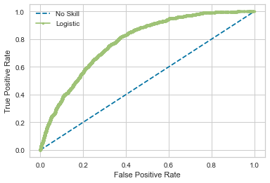

```python
# generate a no skill prediction (majority class)
ns_probs = [0 for _ in range(len(y_test))]
#predict probabilities
lr_probs = lr.predict_proba(X_test)
# keep probabilities for the positive outcome only
lr_probs = lr_probs[:, 1]
# calculate scores
ns_auc = roc_auc_score(y_test, ns_probs)
lr_auc = roc_auc_score(y_test, lr_probs)
# summarize scores
print('No Skill: ROC AUC=%.3f' % (ns_auc))
print('Logistic: ROC AUC=%.3f' % (lr_auc))
# calculate roc curves
ns_fpr, ns_tpr, _ = roc_curve(y_test, ns_probs)
lr_fpr, lr_tpr, _ = roc_curve(y_test, lr_probs)
# plot the roc curve for the model
pyplot.plot(ns_fpr, ns_tpr, linestyle='--', label='No Skill')
pyplot.plot(lr_fpr, lr_tpr, marker='.', label='Logistic')
# axis labels
pyplot.xlabel('False Positive Rate')
pyplot.ylabel('True Positive Rate')
# show the legend
pyplot.legend()
# show the plot
pyplot.show()
```

```python
df_resampled.info()
```

[output not shown]

```python
df_resampled.columns
```

[output not shown]

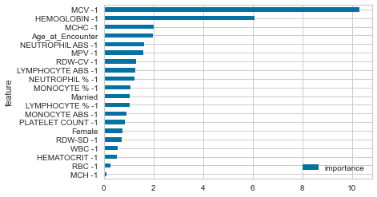

```python
feature_importance = pd.DataFrame(['HEMATOCRIT -1', 'HEMOGLOBIN -1', 'LYMPHOCYTE % -1',
       'LYMPHOCYTE ABS -1', 'MCH -1', 'MCHC -1', 'MCV -1', 'MONOCYTE % -1',
       'MONOCYTE ABS -1', 'MPV -1', 'NEUTROPHIL % -1', 'NEUTROPHIL ABS -1',
       'PLATELET COUNT -1', 'RBC -1', 'RDW-CV -1', 'RDW-SD -1', 'WBC -1',
       'Married', 'Female', 'Age_at_Encounter'], columns = ["feature"])
feature_importance["importance"] = pow(math.e, lr.coef_[0])
feature_importance = feature_importance.sort_values(by = ["importance"], ascending = True)
ax = feature_importance.plot.barh(x = 'feature', y = 'importance')
plt.show()
```

```python
df_resampled.info()
```

[output not shown]